# Simulation 7: IPW with estimated measurement error covariance

Brian Richardson

12/11/2024

```r
rm(list = ls())
library(dplyr)
library(tidyverse)
library(ggplot2)
library(ggh4x)
library(kableExtra)
library(devtools)
load_all()
```

```r
# load simulation results from each of 10 clusters
setwd(dirname(getwd()))
sim.out.list <- lapply(
  X = 0:9,
  FUN = function(clust) {
    cbind(clust,
          read.csv(paste0("sim_data/sim7_ipw_estvar/sd",
                          clust, ".csv")))
  })

# combine simulation results into 1 data frame
sim.out <- bind_rows(sim.out.list)

# true MSM parameters
g <- c(0, 1, 1)

# number of sims per setting
n.rep <- nrow(sim.out) / n_distinct(dplyr::select(sim.out, n, B, k))

# make long data frame
sim.out.long <- sim.out %>%
  pivot_longer(cols = starts_with("ghat") |
                 starts_with("stde") |
                 starts_with("bste"),
               names_to = "method.param",
               values_to = "val") %>%
    mutate(method = factor(substr(method.param, 6, 7),
                           levels = c("NI", "CI"),
                           labels = c("Naive IPW",
                                      "IPW CS")),
           param = factor(substr(method.param, 9, 9)),
           name = factor(substr(method.param, 1, 4)),
           g.true = g[param]) %>%
  dplyr::select(-method.param) %>%
  group_by(clust, n, B, k, n.supp, method, param, name) %>%
  mutate(id = row_number()) %>%
  pivot_wider(names_from = name,
              values_from = val,
              id_cols = c(clust, n, B, k, n.supp, method,
                          param, g.true, id)) %>%
  mutate(ci.lower = ghat - qnorm(0.975) * stde,
         ci.upper = ghat + qnorm(0.975) * stde,
         ci.cov = g.true >= ci.lower & g.true <= ci.upper,
         bcci.lower = ghat - qnorm(0.975) * bste,
         bcci.upper = ghat + qnorm(0.975) * bste,
         bcci.cov = g.true >= bcci.lower & g.true <= bcci.upper)
```

The goal of this program is to evaluate the IPW CS estimator with a nonlinear PS model and for measurement error variance estimated with varying precision.

## Setup

Consider the following setup:

- continuous confounder $L \sim N(0, 0.13)$,
- bivariate continuous exposure $\pmb{A} = (A_1, A_2)^T$ with $\pmb{A}|L$ having multivariate normal distribution $N_2\left(\begin{bmatrix} L^2 \\ -L^2 \end{bmatrix}, \begin{bmatrix} 1 & 0 \\ 0 & 1 \end{bmatrix}\right)$.
- mismeasured exposure $\pmb{A}^* = (A^*_1, A^*_2)^T = \pmb{A} + \pmb{\epsilon}$, where $\pmb{\epsilon} = (\epsilon_1, \epsilon_2)^T \sim N(\pmb{0}, \pmb{\Sigma}_e)$, $\pmb{\Sigma}_e = \begin{bmatrix} 0.2 & 0 \\ 0 & 0.2 \end{bmatrix}$.
- normal outcome $Y$ with $\textrm{E}(Y|\pmb{A},L) = \widetilde\gamma_0 + \widetilde\gamma_1 A_1 + \widetilde\gamma_2 A_2 + \widetilde\gamma_3 L$, where $\widetilde{\pmb{\gamma}} = (\widetilde\gamma_0, \widetilde\gamma_1, \widetilde\gamma_2, \widetilde\gamma_3)^T = (0, 1, 1, 1)^T$.

This data generating process leads to the marginal structural model $\textrm{E}\{Y(\pmb{a})\} = \gamma_0 + \gamma_1 a_1 + \gamma_2 a_2$, where $\pmb{\gamma} = (\gamma_0, \gamma_1, \gamma_2)^T = (0, 1, 1)^T$.

The estimand of interest in these simulations is the parameter $\pmb{\gamma}$ in the marginal structural model.

For these simulations, the covariance $\pmb{\Sigma}_e$ of the measurement error $\pmb{\epsilon}$ is unknown and estimated using supplemental data. In particular, for $n_{supp}$ subjects, we observe $k$ replicates of $\pmb{A}^*$, and estimate $\pmb{\Sigma}_e$ with

$$\widehat{\pmb{\Sigma}}_e =
\frac{\sum_{i=1}^{n_{supp}} \sum_{j=1}^{k} (\pmb{A}^*_{ij} -
\pmb{A}^*_{i.})^{T}(\pmb{A}^*_{ij} -
\pmb{A}^*_{i.})}{\sum_{i=1}^{n_{supp}}(k - 1)}.$$

## Methods

In these simulations, we only look at the IPW CS estimator. We vary the sample size $n$ and the supplemental sample size $n_{supp}$, while holding constant the number of exposure replicates $k = 5$.

## Results

We first check for simulations with errors.

```r
# summarize proportion of missing data by setting
sim.out.long %>%
  group_by(method, n, B, n.supp) %>%
  summarise(prop.error = mean(is.na(ghat))) %>%
  filter(prop.error > 0)
```

```
## # A tibble: 0 × 5
## # Groups:   method, n, B [0]
## # ℹ 5 variables: method <fct>, n <int>, B <int>, n.supp <int>, prop.error <dbl>
```

```r
# extract simulation parameters
n <- unique(sim.out$n)
B <- unique(sim.out$B)
k <- unique(sim.out$k)
n.supp <- unique(sim.out$n.supp)

# make labels for plots
n.labs <- paste0("n = ", n)
names(n.labs) <- n

B.labs <- paste0("B = ", B)
names(B.labs) <- B

n.labs <- paste0("n = ", n)
names(n.labs) <- n

k.labs <- paste0("k = ", k)
names(k.labs) <- k

n.supp.labs <- paste0("Pilot n = ", n.supp)
names(n.supp.labs) <- n.supp

param.labs <- paste0("\u03b3", c("0", "1", "2", "3"))
names(param.labs) <- 1:4

# colorblind friendly pallette
pal_light <- c('#EE6677', '#228833', '#4477AA', '#CCBB44', '#66CCEE', '#AA3377', '#BBBBBB')
pal_dark <- c('#991122', '#114419', '#223b55', '#6b611d', '#117799', '#55193b', '#5d5d5d')
```

```r
# create plots
make.plot <- function(title = F, param. = 2) {

  plot <- sim.out.long %>%
    filter(param == param.,
           method == "IPW CS") %>%
    mutate(n.supp = factor(n.supp)) %>%
    ggplot(aes(x = n.supp, y = ghat)) +
    geom_boxplot(width = 0.7, outlier.size = 0.5) +
    geom_hline(aes(yintercept = g.true),
               linetype = "dashed",
               color = "orange") +
    labs(y = "Parameter Estimate",
         x = "Pilot Sample Size",
         fill = "Method",
         color = "Method") +
    theme_bw() +
    theme(legend.position = "bottom")


  if (title) {
    plot <- plot +
      ggtitle(paste0("Empirical Distribution of Parameter Estimates"),
              subtitle = paste0(n.rep, " simulations per setting"))

  }
  return(plot)
}
```

```r
# create plots
make.plot.2 <- function(title = F, param. = 2) {

  plot <- sim.out.long %>%
    filter(param == param.,
           method == "IPW CS") %>%
    pivot_longer(cols = ends_with(".cov"),
                 names_to = "ci.type",
                 values_to = "ci.cov") %>%
    mutate(ci.type = ifelse(ci.type == "bcci.cov",
                            "Bias-Corrected",
                            "Uncorrected")) %>%
    group_by(n.supp, n, method, ci.type) %>%
    summarise(cov = mean(ci.cov, na.rm = T)) %>%
    ggplot(aes(x = n.supp,
               linetype = ci.type,
               y = cov)) +
    geom_line() +
    geom_hline(yintercept = 0.95,
               linetype = "dashed",
               color = "orange") +
    #facet_grid(n ~ method,
    #           scales = "free",
    #           labeller = labeller(n = n.labs)) +
    labs(y = "Coverage Probability",
         x = "Pilot Sample Size",
         linetype = "CI Type") +
    theme_bw() +
    theme(legend.position = "bottom")

  if (title) {
    plot <- plot +
      ggtitle(paste0("Empirical Coverage Probabilities of 95% Confidence Intervals"),
              subtitle = paste0(n.rep, " simulations per setting"))

  }
  return(plot)
}
```

### Plots of Simulation Results

Below are boxplots of the empirical distributions of estimators for $\gamma_1$, and plots of coverage probabilities of confidence intervals.

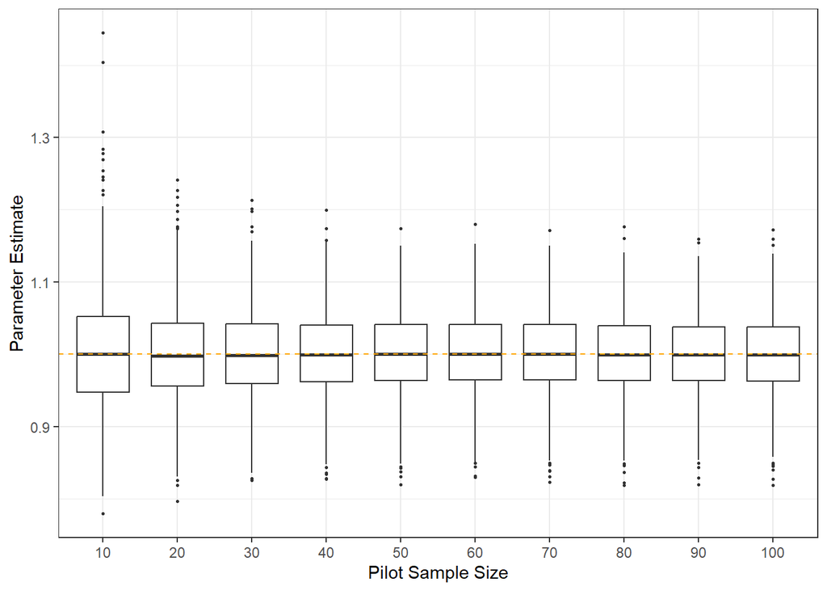

```r
make.plot()
```

```r
# save plot
setwd(dirname(getwd()))
ggsave("sim_figures/sim7_ipw_estvar_1.png",
       width = 6,
       height = 4,
       dpi = 300)
```

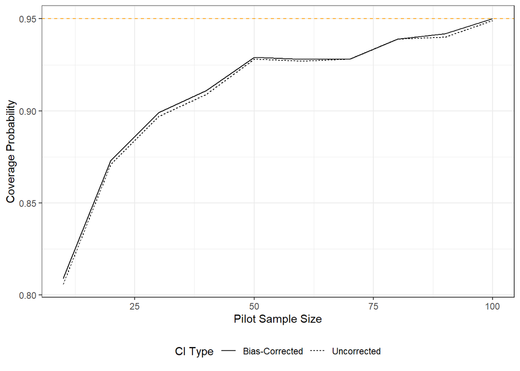

```r
make.plot.2()
```

```r
# save plot
setwd(dirname(getwd()))
ggsave("sim_figures/sim7_ipw_estvar_2.png",
       width = 6,
       height = 4,
       dpi = 300)
```